# R Notebook

```r
library(dplyr)
library(lavaan)
source("HINTS_preprocessing.R")
hints5 <-get_hints5()
```

[output not shown]

```r
boot_times<-1000

zscore <- function(x){
    return((x-mean(x,na.rm=TRUE))/sd(x,na.rm=TRUE))
}
```

```r
table(hints5$GeneralHealth_of) %>% cumsum / sum(!is.na(hints5$GeneralHealth_of))
```

```
## Excellent Very good      Good      Fair      Poor
## 0.1164388 0.4774746 0.8349820 0.9737887 1.0000000
```

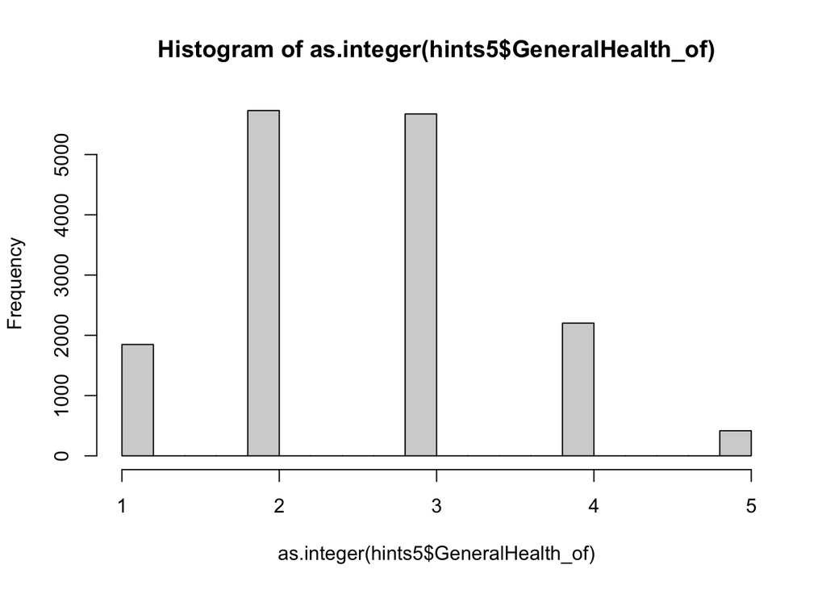

```r
hist(as.integer(hints5$GeneralHealth_of))
```

```r
library(magrittr)
library(dplyr)



data_dir <- "/Users/benjaminsmith/Dropbox (University of Oregon)/UO-SAN Lab/Berkman Lab/Devaluation/analysis_files/data/"

preprocessed_data_filepath <- paste0(data_dir,"cloudresearch_survey_results/orfcs_preprocessed2_anon_by_subj.csv")
library(readr)
library(ggplot2)
library(GGally)
orfcs_dataset <- readr::read_csv(preprocessed_data_filepath)
```

Let’s do our best to include all the same covariates we previously included.

# HINTS dataset: two mediators

This follows Hayes PROCESS Model 6 with two mediators but we are doing it here in Lavaan.

Variables are:

- Treatment: Rurality
- Two Mediators: household income, and fruit and vegetable consumption, in that order.
- Outcome: Physical and health measures. Altogether, we’ll repeat the mediation several times, with the following outcomes variables: BMI, self-rated health, aggregated cardiometabolic health, and high blood pressure. (and cancer??)

This model below is adapted from https://towardsdatascience.com/doing-and-reporting-a-serial-mediation-model-with-two-mediators-in-r-with-lavaan-739ed3155814

I think they’ve left some things out. I need to do a bit more research to work out how to properly implement this, probably including a basic crash course in SEM.

```r
library(stringi)
# [1] "Fruit_vegetables_z~HINTSIsRural_i+Age_c+I(Age_c^2)+RacePP+Gender3C+filename"
# [1] "MedConditions_HighBP_i~Fruit_vegetables_z+HINTSIsRural_i+Age_c+I(Age_c^2)+RacePP+Gender3C+filename"
# IncomeRanges_r

#need to do prepare variables so lavaan can process them
hints5_pp <- hints5
#add quadratic
hints5_pp$Age_c_pow2 <- hints5_pp$Age_c^2


#one-hot some variables
factor_to_clean_string <- function(data, col_to_stringify){
  data[[col_to_stringify]] <- as.character(data[[col_to_stringify]])
  data[[col_to_stringify]] <- (
    str_replace_all(data[[col_to_stringify]],"\\s","_") %>%
      str_replace_all("\\W","")
  )#table(hints5_pp[[col_to_stringify]])
  return(data)
}

hints5_pp<-factor_to_clean_string(hints5_pp,"RacePP2")
hints5_pp$RacePP2<-factor(hints5_pp$RacePP2)
hints5_pp <- mltools::one_hot(hints5_pp,"RacePP2",dropCols = FALSE)
print(paste0(colnames(hints5_pp)[grepl("RacePP2_",colnames(hints5_pp))],collapse=" + "))
```

```
## [1] "RacePP2_American_Indian_or_Alaska_Native + RacePP2_Asian_Indian + RacePP2_Black + RacePP2_Chinese + RacePP2_Filipino + RacePP2_Japanese + RacePP2_Korean + RacePP2_Missing_Data + RacePP2_Multiple_races_selected + RacePP2_Other_Asian + RacePP2_Pacific_Islander + RacePP2_Vietnamese + RacePP2_Wh…
```

```r
hints5_pp<-factor_to_clean_string(hints5_pp,"Gender3C")
hints5_pp$Gender3C<-factor(hints5_pp$Gender3C)
hints5_pp <- mltools::one_hot(hints5_pp,"Gender3C",dropCols = FALSE)
print(paste0(colnames(hints5_pp)[grepl("Gender3C_",colnames(hints5_pp))],collapse=" + "))
```

```
## [1] "Gender3C_Female + Gender3C_Male + Gender3C_MissingOrMultiple"
```

Now prepare the ORFCS dataset for lavaan.

```r
#need to do prepare variables so lavaan can process them
orfcs_dataset_pp <- data.table(orfcs_dataset)
#add quadratic
orfcs_dataset_pp$DEMO_Age_c_pow2 <- orfcs_dataset_pp$DEMO_Age_c^2


#one-hot some variables


orfcs_dataset_pp<-factor_to_clean_string(orfcs_dataset_pp,"RaceC2")
orfcs_dataset_pp$RaceC2<-factor(orfcs_dataset_pp$RaceC2)
orfcs_dataset_pp <- mltools::one_hot(orfcs_dataset_pp,"RaceC2",dropCols = FALSE)
print(paste0(colnames(orfcs_dataset_pp)[grepl("RaceC2_",colnames(orfcs_dataset_pp))],collapse=" + "))
```

```
## [1] "RaceC2_Asian + RaceC2_HawaiianOtherPacificIslander + RaceC2_HispanicAnyRace + RaceC2_OtherRaceRaceNotReported + RaceC2_WhiteOnly"
```

```r
orfcs_dataset_pp<-factor_to_clean_string(orfcs_dataset_pp,"Gender3C")
orfcs_dataset_pp$Gender3C<-factor(orfcs_dataset_pp$Gender3C)
orfcs_dataset_pp <- mltools::one_hot(orfcs_dataset_pp,"Gender3C",dropCols = FALSE)
print(paste0(colnames(orfcs_dataset_pp)[grepl("Gender3C_",colnames(orfcs_dataset_pp))],collapse=" + "))
```

```
## [1] "Gender3C_Female + Gender3C_Male + Gender3C_Other"
```

```r
summary(lm(
  MedConditions_HighBP_i~Fruit_vegetables_z+HINTSIsRural_i+Age_c+I(Age_c^2)+RacePP+Gender3C+filename
  ,hints5_pp))
```

```
##
## Call:
## lm(formula = MedConditions_HighBP_i ~ Fruit_vegetables_z + HINTSIsRural_i +
##     Age_c + I(Age_c^2) + RacePP + Gender3C + filename, data = hints5_pp)
##
## Residuals:
##      Min       1Q   Median       3Q      Max
## -0.97178 -0.40292 -0.06683  0.40747  1.06038
##
## Coefficients:
##                                                          Estimate Std. Error
## (Intercept)                                             1.663e-01  1.376e-02
## Fruit_vegetables_z                                     -2.482e-02  5.483e-03
## HINTSIsRural_i                                          3.126e-02  1.622e-02
## Age_c                                                   1.316e-02  6.651e-04
## I(Age_c^2)                                             -2.565e-05  1.743e-05
## RacePPBlack                                             1.674e-01  1.549e-02
## RacePPMissing data (Not Ascertained)                    5.273e-02  2.439e-02
## RacePPMultiple races selected                           7.050e-02  2.909e-02
## RacePPChinese                                          -5.687e-02  4.937e-02
## RacePPFilipino                                          1.115e-01  5.721e-02
## RacePPAsian Indian                                      4.223e-02  5.738e-02
## RacePPOther Asian                                       1.524e-02  7.300e-02
## RacePPAmerican Indian or Alaska Native                  1.353e-01  7.292e-02
## RacePPPacific Islander                                 -4.762e-02  8.485e-02
## RacePPVietnamese                                        3.070e-02  7.939e-02
## RacePPMissing data (Web partial - Question Never Seen)  5.130e-02  8.812e-02
## RacePPKorean                                           -2.276e-02  8.635e-02
## RacePPJapanese                                          1.033e-01  1.003e-01
## Gender3CMale                                            5.369e-02  1.140e-02
## Gender3CMissingOrMultiple                               3.932e-03  2.399e-02
## filenamehints5_cycle3_public.sav                       -7.891e-03  1.236e-02
##                                                        t value Pr(>|t|)
## (Intercept)                                             12.086  < 2e-16 ***
## Fruit_vegetables_z                                      -4.527 6.09e-06 ***
## HINTSIsRural_i                                           1.927   0.0540 .
## Age_c                                                   19.782  < 2e-16 ***
## I(Age_c^2)                                              -1.472   0.1411
## RacePPBlack                                             10.803  < 2e-16 ***
## RacePPMissing data (Not Ascertained)                     2.162   0.0307 *
## RacePPMultiple races selected                            2.424   0.0154 *
## RacePPChinese                                           -1.152   0.2494
## RacePPFilipino                                           1.950   0.0513 .
## RacePPAsian Indian                                       0.736   0.4617
## RacePPOther Asian                                        0.209   0.8346
## RacePPAmerican Indian or Alaska Native                   1.856   0.0635 .
## RacePPPacific Islander                                  -0.561   0.5746
## RacePPVietnamese                                         0.387   0.6990
## RacePPMissing data (Web partial - Question Never Seen)   0.582   0.5605
## RacePPKorean                                            -0.264   0.7922
## RacePPJapanese                                           1.030   0.3029
## Gender3CMale                                             4.711 2.51e-06 ***
## Gender3CMissingOrMultiple                                0.164   0.8698
## filenamehints5_cycle3_public.sav                        -0.638   0.5233
## ---
## Signif. codes:  0 '***' 0.001 '**' 0.01 '*' 0.05 '.' 0.1 ' ' 1
##
## Residual standard error: 0.4472 on 6870 degrees of freedom
##   (9201 observations deleted due to missingness)
## Multiple R-squared:  0.1921, Adjusted R-squared:  0.1898
## F-statistic: 81.68 on 20 and 6870 DF,  p-value: < 2.2e-16
```

```r
summary(lm(
  MedConditions_HighBP_i~Fruit_vegetables_z+HINTSIsRural_i+Age_c+Age_c_pow2+RacePP+Gender3C+filename
  ,hints5_pp))
```

```
##
## Call:
## lm(formula = MedConditions_HighBP_i ~ Fruit_vegetables_z + HINTSIsRural_i +
##     Age_c + Age_c_pow2 + RacePP + Gender3C + filename, data = hints5_pp)
##
## Residuals:
##      Min       1Q   Median       3Q      Max
## -0.97178 -0.40292 -0.06683  0.40747  1.06038
##
## Coefficients:
##                                                          Estimate Std. Error
## (Intercept)                                             1.663e-01  1.376e-02
## Fruit_vegetables_z                                     -2.482e-02  5.483e-03
## HINTSIsRural_i                                          3.126e-02  1.622e-02
## Age_c                                                   1.316e-02  6.651e-04
## Age_c_pow2                                             -2.565e-05  1.743e-05
## RacePPBlack                                             1.674e-01  1.549e-02
## RacePPMissing data (Not Ascertained)                    5.273e-02  2.439e-02
## RacePPMultiple races selected                           7.050e-02  2.909e-02
## RacePPChinese                                          -5.687e-02  4.937e-02
## RacePPFilipino                                          1.115e-01  5.721e-02
## RacePPAsian Indian                                      4.223e-02  5.738e-02
## RacePPOther Asian                                       1.524e-02  7.300e-02
## RacePPAmerican Indian or Alaska Native                  1.353e-01  7.292e-02
## RacePPPacific Islander                                 -4.762e-02  8.485e-02
## RacePPVietnamese                                        3.070e-02  7.939e-02
## RacePPMissing data (Web partial - Question Never Seen)  5.130e-02  8.812e-02
## RacePPKorean                                           -2.276e-02  8.635e-02
## RacePPJapanese                                          1.033e-01  1.003e-01
## Gender3CMale                                            5.369e-02  1.140e-02
## Gender3CMissingOrMultiple                               3.932e-03  2.399e-02
## filenamehints5_cycle3_public.sav                       -7.891e-03  1.236e-02
##                                                        t value Pr(>|t|)
## (Intercept)                                             12.086  < 2e-16 ***
## Fruit_vegetables_z                                      -4.527 6.09e-06 ***
## HINTSIsRural_i                                           1.927   0.0540 .
## Age_c                                                   19.782  < 2e-16 ***
## Age_c_pow2                                              -1.472   0.1411
## RacePPBlack                                             10.803  < 2e-16 ***
## RacePPMissing data (Not Ascertained)                     2.162   0.0307 *
## RacePPMultiple races selected                            2.424   0.0154 *
## RacePPChinese                                           -1.152   0.2494
## RacePPFilipino                                           1.950   0.0513 .
## RacePPAsian Indian                                       0.736   0.4617
## RacePPOther Asian                                        0.209   0.8346
## RacePPAmerican Indian or Alaska Native                   1.856   0.0635 .
## RacePPPacific Islander                                  -0.561   0.5746
## RacePPVietnamese                                         0.387   0.6990
## RacePPMissing data (Web partial - Question Never Seen)   0.582   0.5605
## RacePPKorean                                            -0.264   0.7922
## RacePPJapanese                                           1.030   0.3029
## Gender3CMale                                             4.711 2.51e-06 ***
## Gender3CMissingOrMultiple                                0.164   0.8698
## filenamehints5_cycle3_public.sav                        -0.638   0.5233
## ---
## Signif. codes:  0 '***' 0.001 '**' 0.01 '*' 0.05 '.' 0.1 ' ' 1
##
## Residual standard error: 0.4472 on 6870 degrees of freedom
##   (9201 observations deleted due to missingness)
## Multiple R-squared:  0.1921, Adjusted R-squared:  0.1898
## F-statistic: 81.68 on 20 and 6870 DF,  p-value: < 2.2e-16
```

```r
#TREAT=HINTSIsRural_i
#m1=IncomeRanges_r
#m2=Fruit_vegetables_z
#OUTCOME=MedConditions_HighBP_i


#NEXT TO DO: DEAL WITH CATEGORICAL DATA. GUIDE HERE: https://lavaan.ugent.be/tutorial/cat.html
hints_model_template=
"
  #Regressions
  IncomeRanges_r ~ ab*HINTSIsRural_i + Age_c + Age_c_pow2 + Gender3C_Male + Gender3C_MissingOrMultiple + RacePP2_American_Indian_or_Alaska_Native + RacePP2_Asian_Indian + RacePP2_Black + RacePP2_Chinese + RacePP2_Filipino + RacePP2_Japanese + RacePP2_Korean + RacePP2_Missing_Data + RacePP2_Multiple_races_selected + RacePP2_Other_Asian + RacePP2_Pacific_Islander + RacePP2_Vietnamese

  Fruit_vegetables_z ~ bc*IncomeRanges_r + ac*HINTSIsRural_i + Age_c + Age_c_pow2 + Gender3C_Male + Gender3C_MissingOrMultiple + RacePP2_American_Indian_or_Alaska_Native + RacePP2_Asian_Indian + RacePP2_Black + RacePP2_Chinese + RacePP2_Filipino + RacePP2_Japanese + RacePP2_Korean + RacePP2_Missing_Data + RacePP2_Multiple_races_selected + RacePP2_Other_Asian + RacePP2_Pacific_Islander + RacePP2_Vietnamese

  (OUTCOMEVAR) ~ cd*Fruit_vegetables_z + bd*IncomeRanges_r + ad*HINTSIsRural_i + Age_c + Age_c_pow2 + Gender3C_Male + Gender3C_MissingOrMultiple + RacePP2_American_Indian_or_Alaska_Native + RacePP2_Asian_Indian + RacePP2_Black + RacePP2_Chinese + RacePP2_Filipino + RacePP2_Japanese + RacePP2_Korean + RacePP2_Missing_Data + RacePP2_Multiple_races_selected + RacePP2_Other_Asian + RacePP2_Pacific_Islander + RacePP2_Vietnamese


  #Defined Parameters:
  indirect_effect := ab*bc*cd
  effect_via_inc_only :=ab*bd
  effect_via_fruit_vege_only :=ac*cd
  direct_effect := ad
"

# - Outcome: Physical and health measures. Altogether, we'll repeat the mediation several times, with the following outcomes variables: BMI, self-rated health, aggregated cardiometabolic health, and high blood pressure.

outcome_measures <- c(
  "BMI",
  "GeneralHealth_i",
  "MedConditionsAggregate",
  "MedConditions_HighBP_i",
  "EverHadCancer_i"#no cancer for now, doesn't seem very important.
  )
```

```r
for (outcome_var in outcome_measures){
  set.seed(05711846)
  hints_model_w_outcome <- str_replace_all(hints_model_template,"\\(OUTCOMEVAR\\)",outcome_var)
  cat(paste0("MEDIATION MODEL FOR OUTCOME: ",outcome_var))
  cat(hints_model_w_outcome)
  fit=sem(
    hints_model_w_outcome,
    hints5_pp,
    se = "bootstrap",
    bootstrap=boot_times,
    likelihood = "wishart")

  summary(fit)
  cat("-----\n\n\n")
}
```

```
## MEDIATION MODEL FOR OUTCOME: BMI
##   #Regressions
##   IncomeRanges_r ~ ab*HINTSIsRural_i + Age_c + Age_c_pow2 + Gender3C_Male + Gender3C_MissingOrMultiple + RacePP2_American_Indian_or_Alaska_Native + RacePP2_Asian_Indian + RacePP2_Black + RacePP2_Chinese + RacePP2_Filipino + RacePP2_Japanese + RacePP2_Korean + RacePP2_Missing_Data + RacePP2_Multip…
##
##   Fruit_vegetables_z ~ bc*IncomeRanges_r + ac*HINTSIsRural_i + Age_c + Age_c_pow2 + Gender3C_Male + Gender3C_MissingOrMultiple + RacePP2_American_Indian_or_Alaska_Native + RacePP2_Asian_Indian + RacePP2_Black + RacePP2_Chinese + RacePP2_Filipino + RacePP2_Japanese + RacePP2_Korean + RacePP2_Missi…
##
##   BMI ~ cd*Fruit_vegetables_z + bd*IncomeRanges_r + ad*HINTSIsRural_i + Age_c + Age_c_pow2 + Gender3C_Male + Gender3C_MissingOrMultiple + RacePP2_American_Indian_or_Alaska_Native + RacePP2_Asian_Indian + RacePP2_Black + RacePP2_Chinese + RacePP2_Filipino + RacePP2_Japanese + RacePP2_Korean + Race…
##
##
##   #Defined Parameters:
##   indirect_effect := ab*bc*cd
##   effect_via_inc_only :=ab*bd
##   effect_via_fruit_vege_only :=ac*cd
##   direct_effect := ad
## lavaan 0.6-11 ended normally after 1 iterations
##
##   Estimator                                         ML
##   Optimization method                           NLMINB
##   Number of model parameters                        57
##
##                                                   Used       Total
##   Number of observations                          6231       16092
##
## Model Test User Model:
##
##   Test statistic                                 0.000
##   Degrees of freedom                                 0
##
## Parameter Estimates:
##
##   Standard errors                            Bootstrap
##   Number of requested bootstrap draws             1000
##   Number of successful bootstrap draws            1000
##
## Regressions:
##                        Estimate    Std.Err  z-value  P(>|z|)
##   IncomeRanges_r ~
##     HINTSIsR_ (ab)         -0.717    0.078   -9.176    0.000
##     Age_c                   0.012    0.004    3.323    0.001
##     Age_c_pw2              -0.001    0.000  -10.837    0.000
```

[output cut: 493 more lines]

```
##
## Variances:
##                    Estimate    Std.Err  z-value  P(>|z|)
##    .IncomeRanges_r      4.425    0.068   65.063    0.000
##    .Fruit_vgtbls_z      0.945    0.016   57.678    0.000
##    .EverHadCancer_      0.117    0.003   42.532    0.000
##
## Defined Parameters:
##                    Estimate    Std.Err  z-value  P(>|z|)
##     indirect_effct     -0.000    0.000   -1.031    0.303
##     effct_v_nc_nly     -0.002    0.002   -1.598    0.110
##     effct_v_frt_v_     -0.000    0.000   -0.798    0.425
##     direct_effect      -0.009    0.013   -0.676    0.499
##
## -----
```

```r
#
# set.seed(05711846)
#
# fit=sem(
#   hints_model,
#   hints5_pp,
#   se = "bootstrap",
#   bootstrap=1000,
#   likelihood = "wishart")
# summary(fit)
```

# Oregon dataset: three mediators

THen, we’ll proceed with our main Oregon dataset analysis.

This follows Hayes PROCESS Model 6 with THREE mediators but we are doing it here in Lavaan.

Variables are:

```r
#TREAT=HINTSIsRural_i
#m1=IncomeRanges_r
#m2=Fruit_vegetables_z
#OUTCOME=MedConditions_HighBP_i


# mb <- lm(MESA_healthyfoodavailability_z~RuralZIP_i+Gender3C+DEMO_Age_c+RaceC2+PSS_z,data_to_measure)
# mc <- lm(BMI~RuralZIP_i+Gender3C+DEMO_Age_c+RaceC2+MESA_healthyfoodavailability_z+PSS_z,data_to_measure)

# [1] "RaceC2_Asian + RaceC2_HawaiianOtherPacificIslander + RaceC2_HispanicAnyRace + RaceC2_OtherRaceRaceNotReported + RaceC2_WhiteOnly"
# [1] "Gender3C_Female + Gender3C_Male + Gender3C_Other"

#NEXT TO DO: DEAL WITH CATEGORICAL DATA. GUIDE HERE: https://lavaan.ugent.be/tutorial/cat.html
oregon_model_template=
"
  #Regressions
  aSES_02_z ~ ab*RuralZIP_i + DEMO_Age_c + DEMO_Age_c_pow2 + Gender3C_Male + Gender3C_Other + RaceC2_Asian + RaceC2_HawaiianOtherPacificIslander + RaceC2_HispanicAnyRace + RaceC2_OtherRaceRaceNotReported

  MESA_healthyfoodavailability_z ~ bc*aSES_02_z + ac*RuralZIP_i + DEMO_Age_c + DEMO_Age_c_pow2 + Gender3C_Male + Gender3C_Other + RaceC2_Asian + RaceC2_HawaiianOtherPacificIslander + RaceC2_HispanicAnyRace + RaceC2_OtherRaceRaceNotReported

  FFQ_fruit_vegetables_z ~ cd*MESA_healthyfoodavailability_z + bd*aSES_02_z + ad*RuralZIP_i + DEMO_Age_c + DEMO_Age_c_pow2 + Gender3C_Male + Gender3C_Other + RaceC2_Asian + RaceC2_HawaiianOtherPacificIslander + RaceC2_HispanicAnyRace + RaceC2_OtherRaceRaceNotReported

  (OUTCOMEVAR) ~ de*FFQ_fruit_vegetables_z + ce*MESA_healthyfoodavailability_z + be*aSES_02_z + ae*RuralZIP_i + DEMO_Age_c + DEMO_Age_c_pow2 + Gender3C_Male + Gender3C_Other + RaceC2_Asian + RaceC2_HawaiianOtherPacificIslander + RaceC2_HispanicAnyRace + RaceC2_OtherRaceRaceNotReported


  #Defined Parameters:
  indirect_effect := ab*bc*cd*de
  d_rural_food_availability := ac
  id_rural_food_availability := ab*bc
  rural_inc_consump := ab*bd*de
  direct_effect := ae
"

# - Outcome: Physical and health measures. Altogether, we'll repeat the mediation several times, with the following outcomes variables: BMI, self-rated health, aggregated cardiometabolic health, and high blood pressure.

outcome_measures <- c(
  "BMI"#,
  #"GeneralHealth_i",
  #"MedConditionsAggregate",
  #"MedConditions_HighBP_i",
  #"EverHadCancer_i"#no cancer for now, doesn't seem very important.
  )
```

```r
for (outcome_var in outcome_measures){
  set.seed(8233042)
  oregon_model_w_outcome <- str_replace_all(oregon_model_template,"\\(OUTCOMEVAR\\)",outcome_var)
  cat(paste0("MEDIATION MODEL FOR OUTCOME: ",outcome_var))
  cat(oregon_model_w_outcome)
  fit=sem(
    oregon_model_w_outcome,
    orfcs_dataset_pp,
    se = "bootstrap",
    bootstrap=boot_times,
    likelihood = "wishart")

  summary(fit)
  cat("-----\n\n\n")
}
```

```
## MEDIATION MODEL FOR OUTCOME: BMI
##   #Regressions
##   aSES_02_z ~ ab*RuralZIP_i + DEMO_Age_c + DEMO_Age_c_pow2 + Gender3C_Male + Gender3C_Other + RaceC2_Asian + RaceC2_HawaiianOtherPacificIslander + RaceC2_HispanicAnyRace + RaceC2_OtherRaceRaceNotReported
##
##   MESA_healthyfoodavailability_z ~ bc*aSES_02_z + ac*RuralZIP_i + DEMO_Age_c + DEMO_Age_c_pow2 + Gender3C_Male + Gender3C_Other + RaceC2_Asian + RaceC2_HawaiianOtherPacificIslander + RaceC2_HispanicAnyRace + RaceC2_OtherRaceRaceNotReported
##
##   FFQ_fruit_vegetables_z ~ cd*MESA_healthyfoodavailability_z + bd*aSES_02_z + ad*RuralZIP_i + DEMO_Age_c + DEMO_Age_c_pow2 + Gender3C_Male + Gender3C_Other + RaceC2_Asian + RaceC2_HawaiianOtherPacificIslander + RaceC2_HispanicAnyRace + RaceC2_OtherRaceRaceNotReported
##
##   BMI ~ de*FFQ_fruit_vegetables_z + ce*MESA_healthyfoodavailability_z + be*aSES_02_z + ae*RuralZIP_i + DEMO_Age_c + DEMO_Age_c_pow2 + Gender3C_Male + Gender3C_Other + RaceC2_Asian + RaceC2_HawaiianOtherPacificIslander + RaceC2_HispanicAnyRace + RaceC2_OtherRaceRaceNotReported
##
##
##   #Defined Parameters:
##   indirect_effect := ab*bc*cd*de
##   d_rural_food_availability := ac
##   id_rural_food_availability := ab*bc
##   rural_inc_consump := ab*bd*de
##   direct_effect := ae
```

```
## lavaan 0.6-11 ended normally after 1 iterations
##
##   Estimator                                         ML
##   Optimization method                           NLMINB
##   Number of model parameters                        46
##
##                                                   Used       Total
##   Number of observations                           618         850
##
## Model Test User Model:
##
##   Test statistic                                 0.000
##   Degrees of freedom                                 0
##
## Parameter Estimates:
##
##   Standard errors                            Bootstrap
##   Number of requested bootstrap draws             1000
##   Number of successful bootstrap draws             993
##
## Regressions:
##                                    Estimate        Std.Err  z-value  P(>|z|)
##   aSES_02_z ~
##     RuralZIP_ (ab)                         -0.352    0.078   -4.484    0.000
##     DEMO_Ag_c                               0.001    0.002    0.525    0.600
##     DEMO_A__2                              -0.000    0.000   -0.008    0.994
##     Gndr3C_Ml                               0.352    0.086    4.101    0.000
##     Gndr3C_Ot                               0.026    0.344    0.075    0.940
##     RacC2_Asn                              -0.214    0.160   -1.331    0.183
##     RcC2_HOPI                               0.304    0.252    1.209    0.227
##     RcC2_HsAR                               0.097    0.181    0.539    0.590
##     RC2_ORRNR                               0.703    0.195    3.603    0.000
##   MESA_healthyfoodavailability_z ~
##     aSES_02_z (bc)                          0.167    0.041    4.073    0.000
##     RuralZIP_ (ac)                         -0.272    0.084   -3.227    0.001
##     DEMO_Ag_c                               0.006    0.002    3.077    0.002
##     DEMO_A__2                              -0.000    0.000   -0.068    0.945
##     Gndr3C_Ml                              -0.057    0.088   -0.650    0.516
##     Gndr3C_Ot                              -0.082    0.339   -0.243    0.808
##     RacC2_Asn                               0.391    0.143    2.731    0.006
```

[output cut: 30 more lines]

```
##                    Estimate        Std.Err  z-value  P(>|z|)
##    .aSES_02_z               0.911    0.038   23.884    0.000
##    .MESA_hlthyfdv_          0.916    0.057   16.182    0.000
##    .FFQ_frt_vgtbl_          0.971    0.047   20.622    0.000
##    .BMI                    52.274    4.173   12.527    0.000
##
## Defined Parameters:
##                    Estimate        Std.Err  z-value  P(>|z|)
##     indirect_effct          0.009    0.005    1.967    0.049
##     d_rrl_fd_vlblt         -0.272    0.084   -3.228    0.001
##     id_rrl_fd_vlbl         -0.059    0.020   -2.892    0.004
##     rural_nc_cnsmp          0.014    0.017    0.872    0.383
##     direct_effect           1.583    0.628    2.519    0.012
##
## -----
```

# Hybrid: three mediators

This follows Hayes PROCESS Model 6 with THREE mediators. We need to somehow manually combine the two datasets by multiplying effects. Need to follow bootstrap analysis, which means we need to extract raw bootstrap results and combine them. I’m not sure it’s feasible, but it would be quite valuable to do.

Variables are: